# The Greatest Offensive Season in NBA History

I want to determine which NBA player had the greatest offensive season of all time. This will be a comprehensive breakdown on player analytics, incorporating aspects of quantitative and qualitative analysis, as well as personal judgement.

# Cleaning the Dataset

There wasn't much work that I needed to put into cleaning the data. The most important change I made was to create a new key value that uniquely represents the player and the season, since some players won multiple MVPs.

# Setting the Criteria

Several categories will be considered before determining which player had the greatest season of all time. Key players with positive outlier statistics wil be added to the best seasons list, and the final selection will be made from players in the list.

# Best Scorers

```
Mean points: 26.188235294117643
Standard deviation for points: 5.1490013141260675
Number of top scorers: 11
```

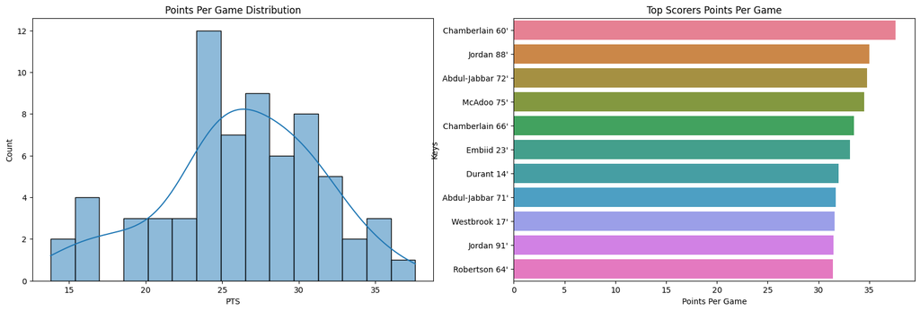

The clear leader in this category is Wilt Chamberlain's 1959-60 season. He eclipsed the rest by a reasonably significant margin, although arguments could be made that he played in a weaker era with a higher scoring pace. Unfortunately, I don't have the data to compare to the average player's points per game in that season, so making I will not make that distinction. Interestingly, Wilt averaged 50 points per game the next season, but he did not win MVP so that season cannot be included.

# Efficiency

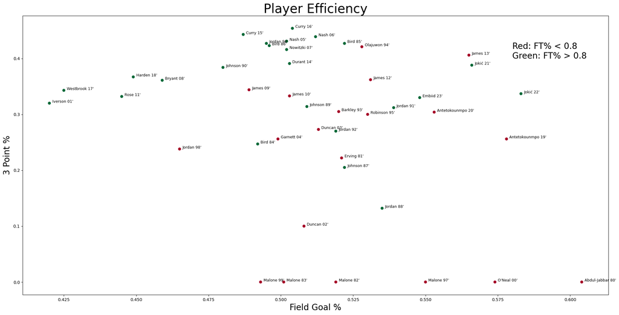

This is admittedly a bit of a confusing plot, but I wanted to encompase all 3 areas of efficiency together. Although there are various extremes in efficiency such as Curry's 2015-16 season and Kareem's 1979-80 season, Jokic's 2021-22 season appears to me as the most all around efficient, considering field goal, 3 point, and free throw efficencies.

# Passing and Rebounding

```
Highest Assist Season: Johnson 89': 12.8 assists per game
Highest Rebound Season: Chamberlain 60': 27.0 rebounds per game
```

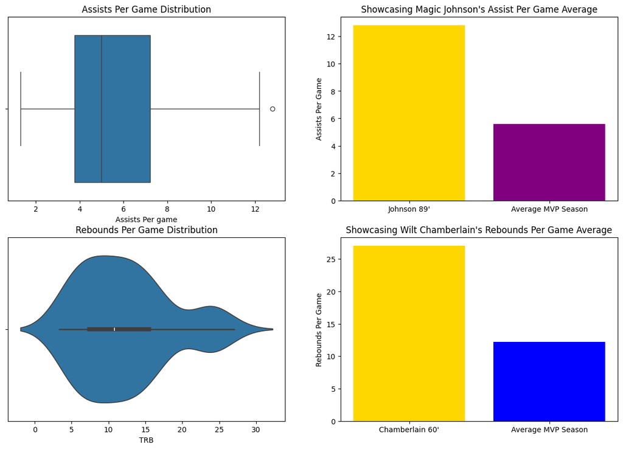

Wilt and Magic both had outstanding seasons relative to their peers respectively in terms of rebounds and assists. Wilt's 1959-60 season has already been added to the best seasons list, so this only further contributes to the case of it being the greatest season of all time. As for Magic, his assists per game average is high enough to be an outlier, even compared to other MVPs.

# Selecting the Best Season

|  | Season | Player | PTS | TRB | AST | FG% |
| --- | --- | --- | --- | --- | --- | --- |
| Johnson 89' | 1988-89 | Magic Johnson | 22.5 | 7.9 | 12.8 | 0.509 |
| Jokić 22' | 2021-22 | Nikola Jokić | 27.1 | 13.8 | 7.9 | 0.583 |
| Chamberlain 60' | 1959-60 | Wilt Chamberlain | 37.6 | 27.0 | 2.3 | 0.461 |

```
PTS correlation with win shares: 0.5327032654168316
TRB correlation with win shares: 0.11886555077461985
AST correlation with win shares: 0.04681177975123693
FG% correlation with win shares: 0.47502460171122984
```

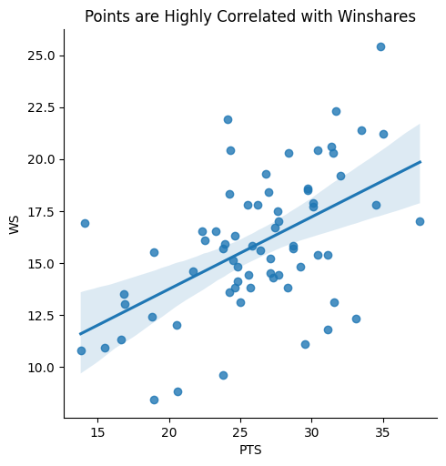

```
Wilt Chamberlain's aggregate offensive impact: 7.37979976
Nikola Jokic's aggregate offensive impact: 5.76960563
Magic Johnson's aggregate offensive impact: 4.23381775
```

Based on my newly created stat, Wilt Chamberlain's 1959-60 season was the greatest offensive season in NBA history. Since scoring is the primary indicator of offensive impact using this stat, it is unsurprising that Wilt wins this one. Nevetheless, Wilt's domninant scoring and rebounding is enough to take the title as having the greatest offensive season in NBA history.

# Recognizing all MVPs

Not just any player is able to become an MVP. After all, only one person in the world will be the NBA's MVP in a single season. So in order to commemorate these players, their name will be displayed with the size of their name indicating the number of MVP awards they won.

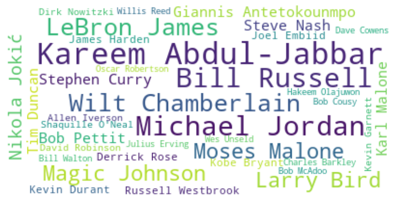

# Conclusion

Many of the greatest players in NBA history were assessed in this analysis, but only a select few were able to surpass their peers significantly in a category. These few include Magic Johnson, Nikola Jokic, and Wilt Chamberlain. In the end, it was determined to be Wilt who had the best offensive season according to the metrics used in the analysis. I would like to present some potential issues with the analysis, though. The statistics used in the analysis are more focused on the stat leaders in a single category, rather than well-rounded numbers that players such as Michael Jordan and Oscar Robertson had in their careers. However, the results of the analysis still speak volumes to Wilt Chamberlain's impact on the game and his dominance during his era.